# Consulting Memo

Carolyn Clayton

Tuesday, January 20, 2015

This is a sample consulting memo originally created to partially fulfill requirements for Consulting II at the University of Colorado Denver.

Dear Sir:

I have performed a two-sample t-test analysis on your data. Below you will find a boxplot of nightly urinations by drug status.

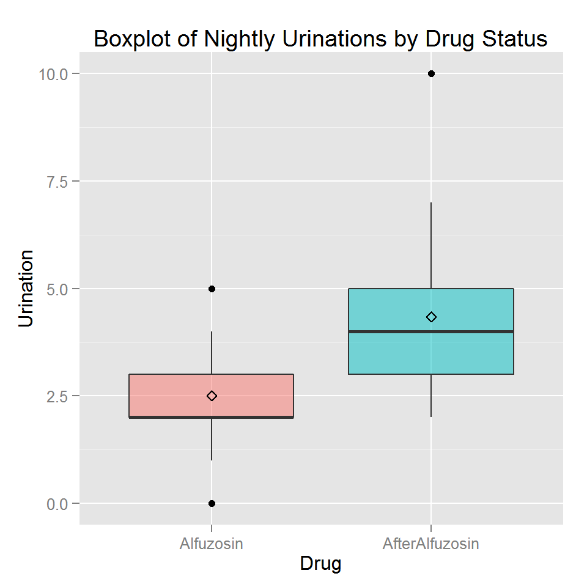

In the analysis of the data, an F test was run to compare the variances of the two groups. This was determined to be significant, F(53, 37) = 0.548, p = 0.044, 95% CI[0.295, 0.984]; therefore a t-test for unequal variances was conducted. The result of this t-test was that there is a significant difference in average nightly urinations between nights on Alfuzosin and off Alfuzosin (t(64.36) = -5.435, p < 0.001, 95% CI[-2.519, -1.165]). The mean nightly urinations on Alfuzosin was 2.5 (SD = 1.314), while the nightly urinations off Alfuzosin was 4.342 (SD = 1.775).

Given these results, we would conclude that alfuzosin is efficacious; however, whether the reduction in night time urinations is sufficient to warrant the potential side effects is left up to your discretion.

Warmly,  
Carolyn